# Active Learning Meetup

Autor: Luiz Matias

29 de outubro de 2020

## Introdução

Hoje em dia é fácil conseguir dados. Porém, conseguir dados rotulados nem tanto. O processo de rotulação pode ser caro e demorado. Nesta situação, como podemos otimizar esse trabalho e escolher os dados certos para rotular? Como garantir que a amostra de dados a serem rotulados não seja redundante ou represente bem a distribuição dos dados como um todo?

Para isso, existe uma técnica chamada Active Learning. O diagrama de como é feito essa técnica é mostrado a seguir. O princípio é escolher de forma inteligente a melhor amostra a ser rotulada com base no seu modelo e nas suas incertezas.

[figure not shown]

Como escolher os melhores dados a serem rotulados? Ao pegar uma amostra em uma região incerta (pode ser visto em um espaço vetorial mais pra frente), certamente vamos obter mais informações do que pegar uma amostra aleatória. Isso é chamado de pool-based sampling. A ideia é pegar os dados que estão em uma região incerta e fazermos a rotulação neles. Mas como pegar esses dados na região incerta? Para isso vamos adotar a estratégia de Uncertainty Sampling (Amostragem de incerteza).

Essa estratégia é mensurada pela fórmula:

[figure not shown]

onde x é a instância a ser prevista e $\widehat{x}$ é a previsão mais provável. Ou seja, ele pega uma amostra com a menor probabilidade de pertencer a determinada classe. (a mais incerta!). Para saber mais, acesse a [documentação do modAL](https://modal-python.readthedocs.io/en/latest/content/query_strategies/uncertainty_sampling.html).

### Importando Bibliotecas

```python
import pandas as pd
from sklearn.svm import SVC
from sklearn import pipeline, feature_extraction
import numpy as np
from modAL.models import ActiveLearner
from sklearn.base import clone
from modAL.uncertainty import uncertainty_sampling
import __init__
from src.plot_functions import plot_distribution, plot_class_predictions, plot_decision_boundary, plot_performance
import warnings
warnings.simplefilter(action='ignore', category=FutureWarning)
```

Criando dados sintéticos XOR onde:

X_raw, y_raw - Dados brutos (shape: 200,2)

X_test, y_test - Dados de teste (shape: 50,2)

```python
rng = np.random.RandomState(0)
X_raw = rng.randn(200, 2)
y_raw = np.logical_xor(X_raw[:, 0] > 0, X_raw[:, 1] > 0).astype(np.int)
rng_test = np.random.RandomState(42)
X_test = rng_test.randn(50, 2)
y_test = np.logical_xor(X_test[:, 0] > 0, X_test[:, 1] > 0).astype(np.int)
```

Vamos iniciar com apenas 5 instâncias nos dados de treinamento rotulados. A outra parte da base de dados bruta, vamos simular um dataset não rotulado que iremos chamar de X_pool, y_pool.

```python
# Isolate our examples for our labeled dataset.
np.random.seed(0)
n_labeled_examples = X_raw.shape[0]
training_indices = np.random.randint(low=0, high=n_labeled_examples + 1, size=5)

X_train = X_raw[training_indices]
y_train = y_raw[training_indices]

# Isolate the non-training examples we'll be querying.
X_pool = np.delete(X_raw, training_indices, axis=0)
y_pool = np.delete(y_raw, training_indices, axis=0)
```

Plotando a distribuição dos dados bruto e de teste em uma espaço vetorial bidimensional

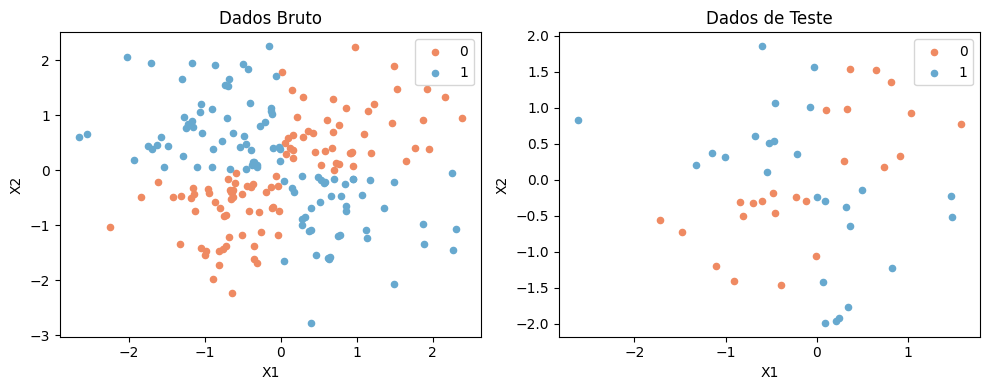

```python
plot_distribution(X_raw, y_raw, X_test, y_test)
```

Vamos utilizar um SVM como modelo. Nele, é preciso habilitar o hiperparâmetro "probability" para que ele possa criar as estimativas de probabilidade. Você pode ler mais sobre na documentação do scikit-learn: https://scikit-learn.org/stable/modules/generated/sklearn.svm.SVC.html

Com isso, vamos começar a utilizar o framework modAL. Ele possui a classe ActiveLearner onde você passa o modelo que você quer utilizar para o seu problema, qual estratégia e os dados de treino. Para saber mais: https://modal-python.readthedocs.io/en/latest/content/models/ActiveLearner.html

```python
# Specify our core estimator along with it's active learning model.
svm = SVC(probability=True, random_state=0)
learner = ActiveLearner(estimator=svm, query_strategy=uncertainty_sampling, X_training=X_train, y_training=y_train)
```

Vamos treinar o nosso modelo na base de treino e fazer a predição na base de dados bruta para sabermos se, somente com a pequena base de treino, ele conseguiria predizer a distribuição dos dados brutos.

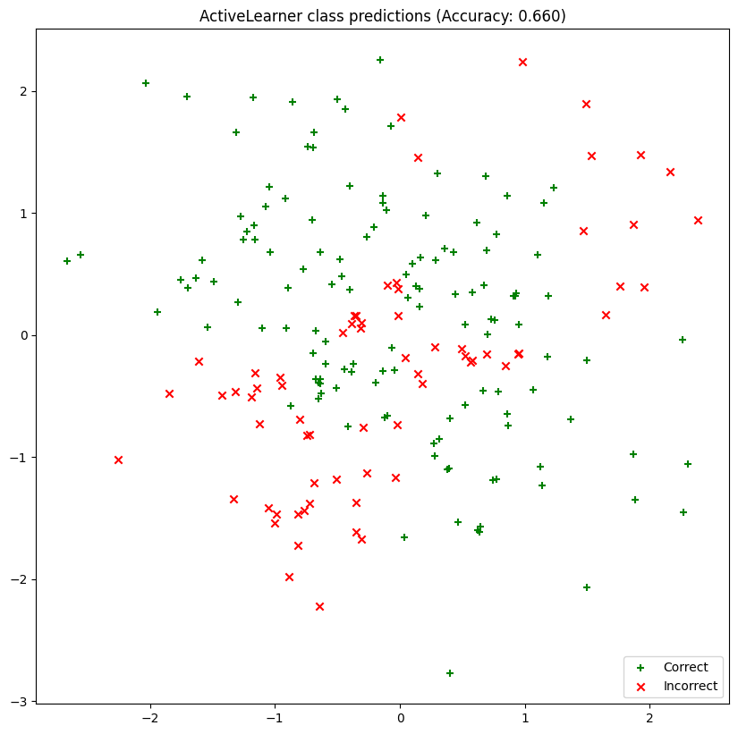

```python
plot_class_predictions(X_raw, y_raw, learner)
```

Como podemos ver, o nosso modelo não foi capaz de aprender adequadamente a distribuição dos dados brutos. Abaixo, vamos ajustar o nosso classificador permitindo que ele consulte 94 instâncias rotuladas que não havia antes. Usando a estratégia de amostragem de incerteza, nosso classificador visa reduzir a quantidade de incerteza em suas previsões usando uma variedade de medidas. Com cada instância solicitada, removemos ela da nossa base de pool e calculamos a acurácia do nosso modelo no conjunto de dados brutos afim de sabermos se o modelo consegue predizer a distribuição dos dados.

```python
N_QUERIES = 94
unqueried_score = learner.score(X_raw, y_raw)
performance_history = [unqueried_score]

X_pool_uncert = X_pool.copy()
y_pool_uncert = y_pool.copy()

lr2 = clone(learner, safe=True)
# Allow our model to query our unlabeled dataset for the most
# informative points according to our query strategy (uncertainty sampling).
for index in range(N_QUERIES):
    query_index, query_instance = lr2.query(X_pool_uncert)

    # Teach our ActiveLearner model the record it has requested.
    X_act, y_act = X_pool_uncert[query_index].reshape(1, -1), y_pool_uncert[query_index].reshape(1, )
    lr2.teach(X=X_act, y=y_act)

    # Remove the queried instance from the unlabeled pool.
    X_pool_uncert, y_pool_uncert = np.delete(X_pool_uncert, query_index, axis=0), np.delete(y_pool_uncert, query_index)

    # Calculate and report our model's accuracy.
    model_accuracy = lr2.score(X_raw, y_raw)
    print('Accuracy after query {n}: {acc:0.4f}'.format(n=index + 1, acc=model_accuracy))

    # Save our model's performance for plotting.
    performance_history.append(model_accuracy)
```

```
Accuracy after query 1: 0.7100
Accuracy after query 2: 0.7750
Accuracy after query 3: 0.6350
Accuracy after query 4: 0.6600
Accuracy after query 5: 0.6350
Accuracy after query 6: 0.8050
Accuracy after query 7: 0.6200
Accuracy after query 8: 0.8100
Accuracy after query 9: 0.8100
Accuracy after query 10: 0.8350
Accuracy after query 11: 0.7800
Accuracy after query 12: 0.8050
Accuracy after query 13: 0.7500
Accuracy after query 14: 0.8050
Accuracy after query 15: 0.8300
Accuracy after query 16: 0.8350
Accuracy after query 17: 0.8750
Accuracy after query 18: 0.8650
Accuracy after query 19: 0.8650
Accuracy after query 20: 0.8650
Accuracy after query 21: 0.8750
Accuracy after query 22: 0.8700
Accuracy after query 23: 0.9000
Accuracy after query 24: 0.9050
Accuracy after query 25: 0.9000
Accuracy after query 26: 0.8950
Accuracy after query 27: 0.8950
Accuracy after query 28: 0.9150
Accuracy after query 29: 0.9000
Accuracy after query 30: 0.9350
Accuracy after query 31: 0.9250
Accuracy after query 32: 0.9150
Accuracy after query 33: 0.8750
Accuracy after query 34: 0.9100
Accuracy after query 35: 0.9550
Accuracy after query 36: 0.8900
Accuracy after query 37: 0.9250
Accuracy after query 38: 0.9300
Accuracy after query 39: 0.9450
Accuracy after query 40: 0.8750
```

[output cut: 39 more lines]

```
Accuracy after query 80: 0.9800
Accuracy after query 81: 0.9750
Accuracy after query 82: 0.9650
Accuracy after query 83: 0.9600
Accuracy after query 84: 0.9750
Accuracy after query 85: 0.9700
Accuracy after query 86: 0.9700
Accuracy after query 87: 0.9700
Accuracy after query 88: 0.9600
Accuracy after query 89: 0.9850
Accuracy after query 90: 0.9850
Accuracy after query 91: 0.9750
Accuracy after query 92: 0.9800
Accuracy after query 93: 0.9850
Accuracy after query 94: 0.9850
```

Agora vamos fazer a mesma coisa que fizemos utilizando a estratégia de amostragem incerta porém pegando novas instâncias de forma aleatória. Em seguida, vamos comparar os resultados

```python
N_QUERIES = 94
svm.fit(X_train, y_train)
unqueried_score_random = svm.score(X_raw, y_raw)
performance_history_random = [unqueried_score_random]

X_pool_random = X_pool.copy()
y_pool_random = y_pool.copy()

X_train_new = X_train.copy()
y_train_new = y_train.copy()
# Allow our model to query our unlabeled dataset for the most
# informative points according to our query strategy (uncertainty sampling).

for index in range(N_QUERIES):
    np.random.seed(1234)
    query_index = np.random.randint(low=0, high=X_pool_random.shape[0])
    query_instance = [X_pool[query_index].tolist()]
    # Teach our ActiveLearner model the record it has requested.
    X_random, y_random = X_pool_random[query_index].reshape(1, -1), y_pool_random[query_index].reshape(1, )

    X_train_new = np.concatenate((X_train_new, X_random))
    y_train_new = np.concatenate((y_train_new, y_random))

    svm.fit(X_train_new, y_train_new)


    # Remove the queried instance from the unlabeled pool.
    X_pool_random, y_pool_random = np.delete(X_pool_random, query_index, axis=0), np.delete(y_pool_random, query_index)

    # Calculate and report our model's accuracy.
    model_accuracy = svm.score(X_raw, y_raw)
    print('Accuracy after query {n}: {acc:0.4f}'.format(n=index + 1, acc=model_accuracy))

    # Save our model's performance for plotting.
    performance_history_random.append(model_accuracy)
```

```
Accuracy after query 1: 0.6350
Accuracy after query 2: 0.6250
Accuracy after query 3: 0.5900
Accuracy after query 4: 0.5950
Accuracy after query 5: 0.5850
Accuracy after query 6: 0.7050
Accuracy after query 7: 0.7300
Accuracy after query 8: 0.7200
Accuracy after query 9: 0.7250
Accuracy after query 10: 0.7400
Accuracy after query 11: 0.7550
Accuracy after query 12: 0.7550
Accuracy after query 13: 0.7600
Accuracy after query 14: 0.7400
Accuracy after query 15: 0.7900
Accuracy after query 16: 0.7900
Accuracy after query 17: 0.7850
Accuracy after query 18: 0.7900
Accuracy after query 19: 0.7400
Accuracy after query 20: 0.7900
Accuracy after query 21: 0.7900
Accuracy after query 22: 0.7800
Accuracy after query 23: 0.7700
Accuracy after query 24: 0.7800
Accuracy after query 25: 0.7800
Accuracy after query 26: 0.8400
Accuracy after query 27: 0.8350
Accuracy after query 28: 0.8450
Accuracy after query 29: 0.8400
Accuracy after query 30: 0.8400
Accuracy after query 31: 0.8400
Accuracy after query 32: 0.8400
Accuracy after query 33: 0.8350
Accuracy after query 34: 0.8350
Accuracy after query 35: 0.8450
Accuracy after query 36: 0.8300
Accuracy after query 37: 0.8300
Accuracy after query 38: 0.8500
Accuracy after query 39: 0.8500
Accuracy after query 40: 0.8500
```

[output cut: 39 more lines]

```
Accuracy after query 80: 0.9150
Accuracy after query 81: 0.9150
Accuracy after query 82: 0.9100
Accuracy after query 83: 0.9100
Accuracy after query 84: 0.9100
Accuracy after query 85: 0.9100
Accuracy after query 86: 0.9100
Accuracy after query 87: 0.9150
Accuracy after query 88: 0.9050
Accuracy after query 89: 0.9150
Accuracy after query 90: 0.9150
Accuracy after query 91: 0.9300
Accuracy after query 92: 0.9300
Accuracy after query 93: 0.9150
Accuracy after query 94: 0.9150
```

Abaixo podemos ver o limite de decisão do nosso classificador SVM utilizando active learning e de forma aleatória

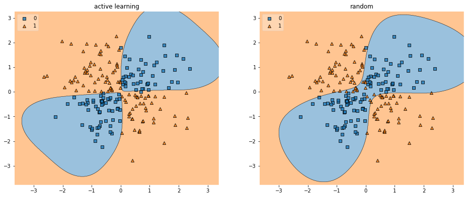

```python
plot_decision_boundary(X_raw, y_raw, lr2, svm)
```

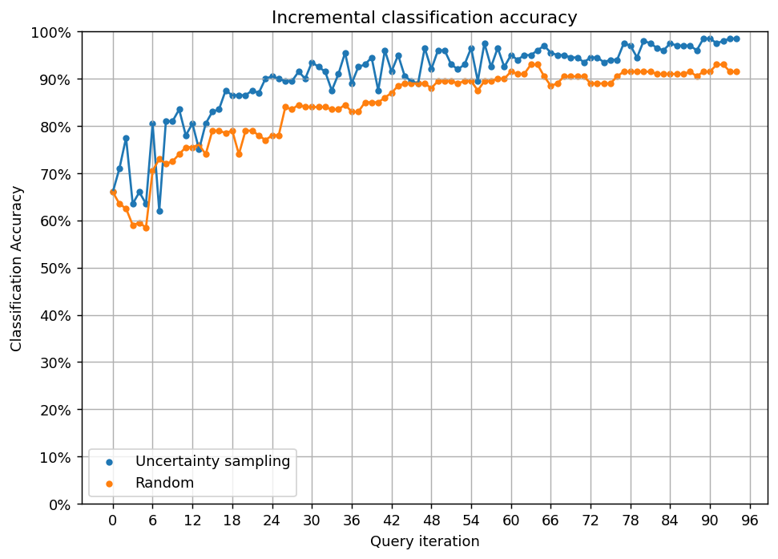

```python
plot_performance(performance_history_random, performance_history)
```

```python
print(f'Acurácia na base de teste utilizando active learning: {lr2.score(X_test, y_test)}')
print(f'Acurácia na base de teste pegando instâncias de forma aleatória: {svm.score(X_test, y_test)}')
```

```
Acurácia na base de teste utilizando active learning: 0.98
Acurácia na base de teste pegando instâncias de forma aleatória: 0.92
```

### Depois de quantas novas instâncias a amostragem aleatória obteve a mesma acurácia da estratégia de amostragem de incerteza?

Após 170 novas instâncias, a amostragem aleatória conseguiu atingir a mesma acurácia da amostragem de incerteza.

[figure not shown]

# Problema de Classificação de Texto

Nesse exemplo, vamos utilizar o dataset 20 newsgroups que é um problema de classificação de texto. Para simplificar, vamos utilizar somente três classes: Baseball, Hockey e Motorcycles. Para saber mais sobre esse dataset: https://scikit-learn.org/stable/modules/generated/sklearn.datasets.fetch_20newsgroups.html

### Importando Bibliotecas

```python
from sklearn.datasets import fetch_20newsgroups
from modAL.uncertainty import uncertainty_sampling
from sklearn.pipeline import Pipeline
from sklearn.feature_extraction.text import TfidfVectorizer
from sklearn.base import clone
from sklearn.model_selection import train_test_split
from sklearn.svm import SVC
from src.preprocessing_functions import clean_text
from src.plot_functions import plot_density_distribution, plot_dimensionality_reduction_distribution
```

Criando os dados brutos e de teste. Vamos comparar a estratégia de amostra de incerteza com a amostra aleatória na base de teste.

```python
categories = ['rec.sport.baseball', 'rec.sport.hockey', 'rec.motorcycles']
twenty_raw = fetch_20newsgroups(subset= 'train', categories=categories, shuffle=True, random_state=42, remove=('headers', 'footers', 'quotes'))
twenty_test = fetch_20newsgroups(subset='test', categories=categories, shuffle=True, random_state=42, remove=('headers', 'footers', 'quotes'))
```

Criando o dataset com a feature textual e a target.

```python
raw_data = pd.DataFrame(twenty_raw.data, columns=['Text'])
raw_data['target'] = twenty_raw.target
test_data = pd.DataFrame(twenty_test.data, columns=['Text'])
test_data['target'] = twenty_test.target
```

Limpando os dados textuais. Retirando stop words, dados númericos, caracteres indesejados e colocando tudo minúsculo

```python
%%time
raw_data['text_clean'] = list(map(clean_text, raw_data['Text'].fillna('')))
test_data['text_clean'] = list(map(clean_text, test_data['Text'].fillna('')))
```

```
CPU times: user 1.31 s, sys: 0 ns, total: 1.31 s
Wall time: 1.31 s
```

```python
raw_data.head()
```

|  | Text | target | text_clean |
| --- | --- | --- | --- |
| 0 | Posted for a friend:\n\nLooking for tires, dim... | 0 | posted friend looking tires dimensions also lo... |
| 1 | \na lot of batters lean in when pitches come. ... | 1 | lot batters lean pitches come rickey crouch te... |
| 2 | \nI tell you, Steve Stone is like a prophet.\n... | 1 | tell steve stone like prophet must making ton ... |
| 3 | \nTheir phone number is 1-800-377-9777. The la... | 1 | phone number last catalog shows three oaks jer... |
| 4 | \n\nAnd some comments, with some players delet... | 1 | comments players deleted yep kevin mitchell ne... |

retirando linhas vazias

```python
raw_data =  raw_data[(raw_data['text_clean'] != '') & (raw_data['text_clean'] != ' ')].reset_index(drop=True)
test_data =  test_data[(test_data['text_clean'] != '') & (test_data['text_clean'] != ' ')].reset_index(drop=True)
```

```python
raw_data.target.value_counts()
```

```
2    584
0    583
1    572
Name: target, dtype: int64
```

Separando o dataset bruto em dados de base e dados pool. Os dados pool é a simulação dos dados não rotulados. Dados de base são os dados rotulados. Vamos ter, inicialmente, apenas 5% de dados rotulados!

```python
df_base, df_pool = train_test_split(raw_data, test_size= 0.95, random_state=42)
```

Podemos notar que as classes estão balanceadas

```python
df_base.target.value_counts()
```

```
0    33
1    29
2    24
Name: target, dtype: int64
```

```python
df_pool.target.value_counts()
```

```
2    560
0    550
1    543
Name: target, dtype: int64
```

Analisando a distribuição dos dados de base em um espaço vetorial bidimensional. Foi utilizado o SVD truncado, nesse contexto é conhecido como LSA. Este transformador realiza a redução da dimensionalidade linear por meio da decomposição de valor singular truncado (SVD). Ao contrário do PCA, este estimador não centraliza os dados antes de calcular a decomposição de valor singular. Isso significa que ele pode trabalhar com matrizes esparsas de forma eficiente. Saiba mais: https://scikit-learn.org/stable/modules/generated/sklearn.decomposition.TruncatedSVD.html

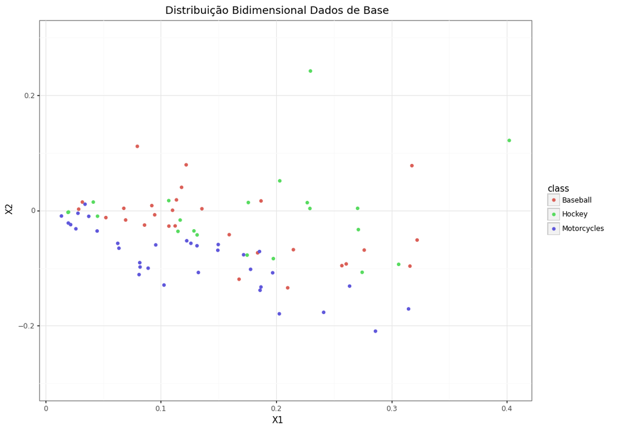

```python
plot_dimensionality_reduction_distribution(df_base.text_clean, df_base.target, 'Distribuição Bidimensional Dados de Base')
```

Criando o pipeline do nosso modelo. Vamos utilizar o TfidfVectorizer para converter os dados textuais em uma matriz TF-IDF (saiba mais: https://scikit-learn.org/stable/modules/generated/sklearn.feature_extraction.text.TfidfVectorizer.html) e usar um modelo de classificação SVM. Nele, é preciso habilitar o hiperparâmetro "probability" para que ele possa criar as estimativas de probabilidade. E foi colocado o hiperparâmetro "class_weight" para balanceado. Isso utiliza a quantidade das classes para ajustar automaticamente os pesos inversamente proporcional às frequências da classe. (saiba mais https://scikit-learn.org/stable/modules/generated/sklearn.svm.SVC.html)

```python
model = Pipeline(steps=[
    ('tfidf', TfidfVectorizer()),
    ('SVM', SVC(probability=True, random_state=42, class_weight='balanced'))
])
```

Separando nossa feature textual e o target nos nossos dados de base

```python
X_base = df_base.text_clean
y_base = df_base.target
```

Separando nossa feature textual e o target nos nossos dados de teste

```python
X_test = test_data.text_clean
y_test = test_data.target
```

Treinando o modelo para ver o quanto de acurácia inicial teremos nos dados de teste.

```python
model.fit(X_base, y_base)
```

```
Pipeline(steps=[('tfidf', TfidfVectorizer()),
                ('SVM',
                 SVC(class_weight='balanced', probability=True,
                     random_state=42))])
```

```python
first_accuracy = np.round(model.score(X_test, y_test), 4)
first_accuracy
```

```
0.636
```

Vamos criar uma lista com os dados de base. A medida que as instâncias forem sendo escolhidas e rotuladas, vamos alimentando essas listas.

```python
X_list_base = []
y_list_base = []
X_list_base += df_base.text_clean.tolist()
y_list_base += df_base.target.tolist()
```

### Estratégia utilizada: amostragem de incerteza

**modAL.uncertainty.uncertainty_sampling()**

Estratégia de consulta de amostragem de incerteza. Seleciona as instâncias menos seguras para rotulagem.

**Parameters**:

**classifier** – O classificador

**X** – A amostra de pool para ser rotulada

**n_instances** – Quantas instâncias para serem rotuladas

**Retorna:**

Os índices das instâncias de X escolhidas para serem rotuladas; as instâncias de X escolhidas para serem rotuladas.

source: https://modal-python.readthedocs.io/en/latest/content/apireference/uncertainty.html

Vamos repetir o processo de rotulação 35 vezes. Cada amostra terão 5 instâncias novas. Essas instâncias serão inseridas na lista de dados de base e retiradas dos dados de pool (dados não rotulados). A cada amostra, vamos verificar a acurácia na base de teste. Primeiro, vamos fazer esse processo utilizando active learning com a estratégia de amostragem de incerteza.

```python
# 35 amostras de 5 instâncias  para serem rotuladas
N_AMOSTRAS = 35
N_INSTANCES = 5
performance_history_active = [first_accuracy]

df_pool_active = df_pool.copy().reset_index(drop=True)

X_list_active = X_list_base.copy()
y_list_active = y_list_base.copy()

for index in range(N_AMOSTRAS):

    model_active = clone(model)
    model_active.fit(X_list_active, y_list_active)

    new_index, new_text = uncertainty_sampling(model_active, df_pool_active.text_clean, n_instances=N_INSTANCES)

    X_list_active += new_text.tolist()
    y_list_active += df_pool_active.loc[new_index].target.tolist()

    df_pool_active.drop(new_index, inplace=True)
    df_pool_active.reset_index(drop=True, inplace=True)

    model_acc = clone(model)
    model_acc.fit(X_list_active, y_list_active)
    score_test = model_acc.score(X_test, y_test)
    print('Accuracy after query {n}: {acc:0.4f}'.format(n=(index + 1) * N_INSTANCES, acc=score_test))
    performance_history_active.append(score_test)
```

```
Accuracy after query 5: 0.6690
Accuracy after query 10: 0.7262
Accuracy after query 15: 0.7296
Accuracy after query 20: 0.7877
Accuracy after query 25: 0.8111
Accuracy after query 30: 0.8024
Accuracy after query 35: 0.7920
Accuracy after query 40: 0.8120
Accuracy after query 45: 0.8050
Accuracy after query 50: 0.8059
Accuracy after query 55: 0.8068
Accuracy after query 60: 0.8068
Accuracy after query 65: 0.7946
Accuracy after query 70: 0.7842
Accuracy after query 75: 0.8007
Accuracy after query 80: 0.7990
Accuracy after query 85: 0.8250
Accuracy after query 90: 0.8094
Accuracy after query 95: 0.8042
Accuracy after query 100: 0.8120
Accuracy after query 105: 0.8258
Accuracy after query 110: 0.8302
Accuracy after query 115: 0.8302
Accuracy after query 120: 0.8362
Accuracy after query 125: 0.8328
Accuracy after query 130: 0.8406
Accuracy after query 135: 0.8440
Accuracy after query 140: 0.8440
Accuracy after query 145: 0.8518
Accuracy after query 150: 0.8406
Accuracy after query 155: 0.8449
Accuracy after query 160: 0.8432
Accuracy after query 165: 0.8449
Accuracy after query 170: 0.8458
Accuracy after query 175: 0.8579
```

Analisando a distribuição das instâncias após o active learning

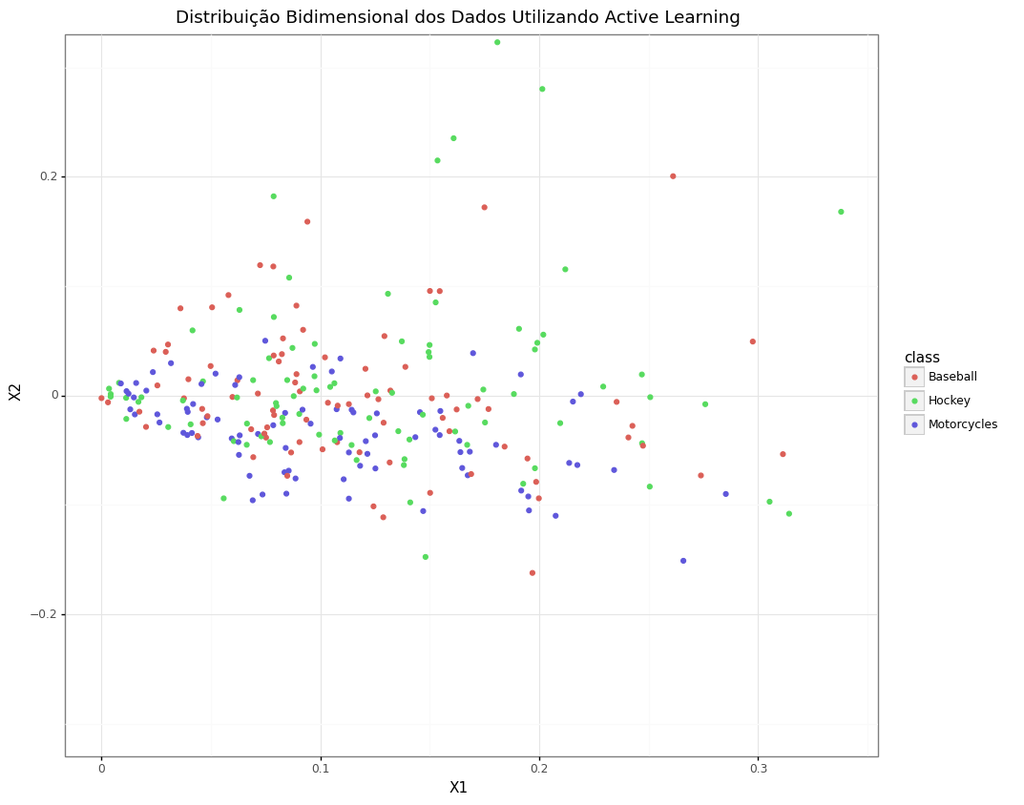

```python
plot_dimensionality_reduction_distribution(X_list_active, y_list_active, 'Distribuição Bidimensional dos Dados Utilizando Active Learning')
```

Vamos repetir o processo utilizando instâncias aleatórias

```python
#35 amostras de 5 instâncias  para serem rotuladas
N_AMOSTRAS = 35
N_INSTANCES = 5
performance_history_random = [first_accuracy]

df_pool_random = df_pool.copy().reset_index(drop=True)

X_list_random = X_list_base.copy()
y_list_random = y_list_base.copy()

for index in range(N_AMOSTRAS):
    np.random.seed(0)

    new_index = list(np.random.randint(low=0, high=df_pool_random.shape[0], size= N_INSTANCES))
    new_text = df_pool_random.loc[new_index].text_clean
    X_list_random += new_text.tolist()
    y_list_random += df_pool_random.loc[new_index].target.tolist()

    df_pool_random.drop(new_index, inplace=True)
    df_pool_random.reset_index(drop=True, inplace=True)

    model_acc = clone(model, safe=True)
    model_acc.fit(X_list_random, y_list_random)
    score_test = model_acc.score(X_test, y_test)
    print('Accuracy after query {n}: {acc:0.4f}'.format(n=(index + 1) * N_INSTANCES, acc=score_test))
    performance_history_random.append(score_test)
```

```
Accuracy after query 5: 0.6551
Accuracy after query 10: 0.6863
Accuracy after query 15: 0.6594
Accuracy after query 20: 0.6828
Accuracy after query 25: 0.7114
Accuracy after query 30: 0.7158
Accuracy after query 35: 0.7383
Accuracy after query 40: 0.7383
Accuracy after query 45: 0.7288
Accuracy after query 50: 0.7340
Accuracy after query 55: 0.7166
Accuracy after query 60: 0.7028
Accuracy after query 65: 0.7296
Accuracy after query 70: 0.7305
Accuracy after query 75: 0.7201
Accuracy after query 80: 0.7114
Accuracy after query 85: 0.7114
Accuracy after query 90: 0.7088
Accuracy after query 95: 0.7158
Accuracy after query 100: 0.7253
Accuracy after query 105: 0.7357
Accuracy after query 110: 0.7357
Accuracy after query 115: 0.7392
Accuracy after query 120: 0.7574
Accuracy after query 125: 0.7678
Accuracy after query 130: 0.7574
Accuracy after query 135: 0.7626
Accuracy after query 140: 0.7721
Accuracy after query 145: 0.7834
Accuracy after query 150: 0.7868
Accuracy after query 155: 0.7929
Accuracy after query 160: 0.7981
Accuracy after query 165: 0.8033
Accuracy after query 170: 0.7955
Accuracy after query 175: 0.7946
```

Analisando a distribuição das instâncias após as escolhas aleatórias

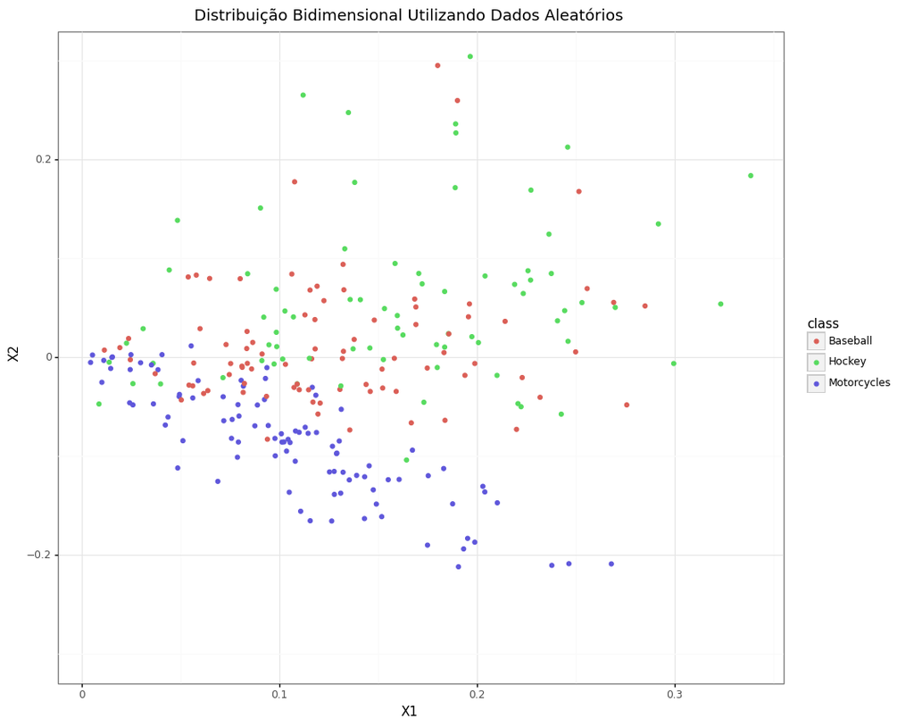

```python
plot_dimensionality_reduction_distribution(X_list_random, y_list_random, 'Distribuição Bidimensional Utilizando Dados Aleatórios')
```

Vamos agora plotar a distribuição dos dados brutos em uma espaço vetorial bidimensional. Assim, teremos uma ideia de onde estão cada classe e onde é o limite de decisão.

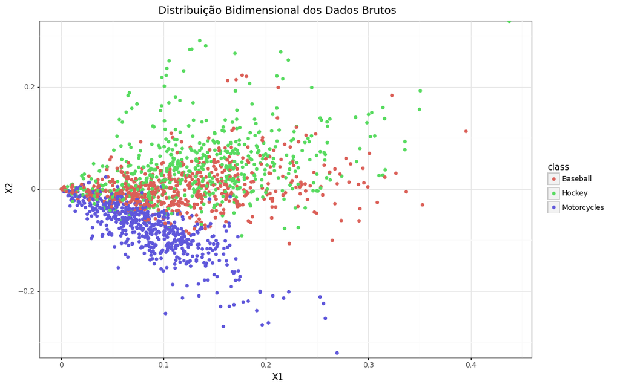

```python
plot_dimensionality_reduction_distribution(raw_data.text_clean, raw_data.target, 'Distribuição Bidimensional dos Dados Brutos')
```

Podemos ver nos gráficos abaixo que utilizando a técnica de Active Learning, os dados estão mais concentrados onde é o limite de decisão. As instâncias aleatórias estão mais espalhadas no espaço bidimensional.

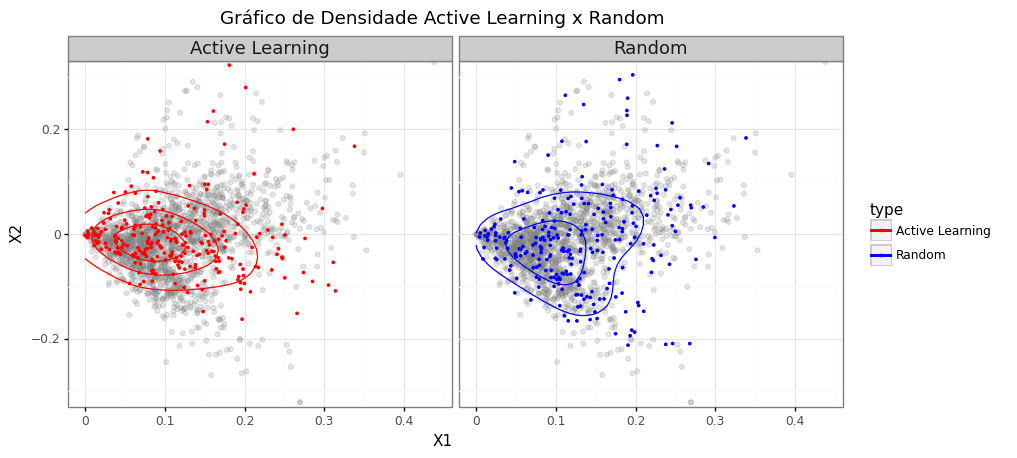

```python
plot_density_distribution(raw_data.text_clean, X_list_active, X_list_random)
```

No gráfico abaixo, podemos ver a relação das amostras (cada uma possui 5 instâncias) em relação a acurácia do classificador. É observado que utilizando a técnica active learning, tivemos uma performance melhor em relação as instâncias escolhidas aleatoriamente.

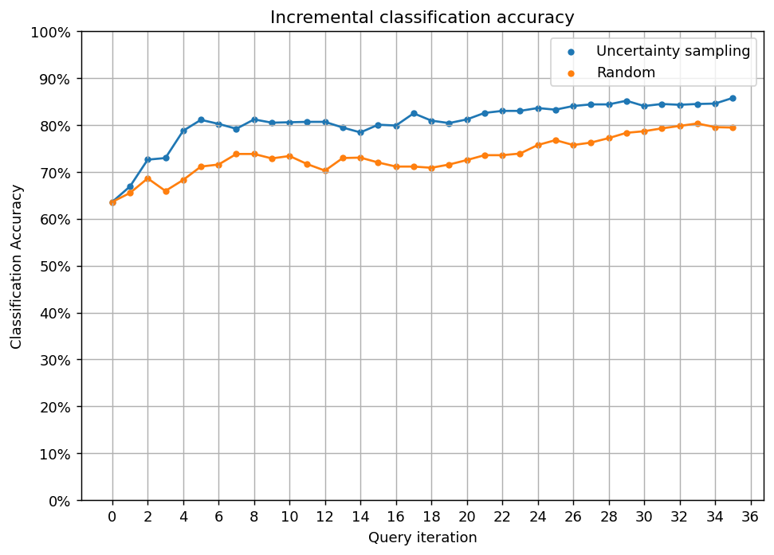

```python
plot_performance(performance_history_random, performance_history_active)
```

## Sources

- http://burrsettles.com/pub/settles.activelearning.pdf
- https://modal-python.readthedocs.io/en/latest/
- https://medium.com/towards-artificial-intelligence/how-to-use-active-learning-to-iteratively-improve-your-machine-learning-models-1c6164bdab99
- https://medium.com/@tivadar.danka/how-to-use-unlabelled-data-to-get-more-training-data-218f300fffe4
- https://www.youtube.com/watch?v=0efyjq5rWS4
- https://arxiv.org/pdf/1805.00979.pdf
- https://towardsdatascience.com/active-learning-tutorial-57c3398e34d
- https://github.com/modAL-python/modAL